# Build and explore phyloseq object

Mateu Menendez Serra (mateu.menendez@sund.ku.dk)

2026-05-27

# Overview

In this practical, you will explore alpha- and beta-diversity patterns using the data you generated in previous sessions.

To do this, you will first learn how to organise microbiome data into a **phyloseq** object and how to use the built-in functions that phyloseq offers for:

- data handling
- visualisation
- data transformation
- alpha- and beta-diversity estimation and visualisation
- and more.

You can find a complete phyloseq user guide [here](https://joey711.github.io/phyloseq/).

The sessions will be conducted in **R** and, therefore, during these practicals we will not work in the terminal as in previous sessions. Instead, we will use RStudio. To simplify the individual setup, package installation, and dependency management, we will use a Binder environment that allows us to run RStudio directly in the browser.

To launch the Binder environment, go to the repository main page, switch to the **r-studio** branch, and follow the instructions. Once loaded, you will be able to work in an RStudio-like environment running in your browser, with the repository available as the working directory.

> **Working directory layout**

> ```
> week20_rmd_scripts
> ├── 01_build_and_explore_phyloseq_object.Rmd
> ├── 02_statistical_testing_of_alpha_diversity.Rmd
> └── 03_...
>
> data/
> ├── mag_table.tsv
> ├── sample_data.tsv
> ├── tax_table.tsv
> ├── gtdb_mag_tree.tree
> └── phyloseq_augmented.rds
> ```

# 1. Phyloseq

## Introduction to phyloseq

`phyloseq` is an R package specifically designed for the analysis and visualisation of microbiome data. It provides a unified framework to integrate different types of information commonly generated in microbial community studies, including taxonomic abundance tables, sample metadata, taxonomic classifications, and phylogenetic trees. By storing all these components within a single object, phyloseq simplifies data handling and allows users to perform downstream analyses such as diversity estimation, ordination, filtering, and visualisation in a consistent and reproducible way.

## Step 1: Create the phyloseq object

In R, most functionality is organised into **packages**, which are collections of functions and tools designed for specific types of analyses. Before starting, we need to load the packages that we will use throughout the practical.

In this session:

- `phyloseq` will be used to organise and analyse microbiome data.
- `tidyverse` provides a collection of useful packages for data manipulation and visualisation.
- `ape` contains tools for handling and visualising phylogenetic trees.

You can load packages in R using the `library()` function:

```r
library(phyloseq)
library(tidyverse)
library(ape)
library(tibble)
```

Once the packages are loaded, the first step is to load the independent files containing the different components of our microbiome dataset.

In this example, we will load:

- an abundance table (`mag_table.tsv`) containing MAG abundances across samples,
- a taxonomy table (`tax_table.tsv`) containing the taxonomic classification of each MAG,
- and a metadata table (`sample_data.tsv`) containing information associated with each sample.

```r
data_dir <- "../data"

# mag_table.tsv
# - first column: MAG IDs
# - remaining columns: samples
# - values: abundance values for each MAG in each sample

otu_df <- read.delim(
  file.path(data_dir, "mag_table.tsv"),
  check.names = FALSE
)


# tax_table.tsv
# - first column: MAG IDs
# - remaining columns: taxonomy ranks

tax_df <- read.delim(
  file.path(data_dir, "tax_table.tsv"),
  check.names = FALSE
)


# sample_data.tsv
# - first column: sample IDs
# - remaining columns: metadata variables

sample_df <- read.delim(
  file.path(data_dir, "sample_data.tsv"),
  check.names = FALSE
)
```

Additionally, to fully explore the capabilities of phyloseq, we have included a phylogenetic tree linking the MAGs. Since the MAGs were taxonomically annotated with GTDB-Tk using the GTDB taxonomy, we can use the phylogenetic tree provided by GTDB as part of the resources distributed with each release: https://data.gtdb.aau.ecogenomic.org

```r
# gtdb_mag_tree.tree
# - Newick tree
# - tip labels must match the MAG IDs used in the abundance table

tree <- ape::read.tree(file.path(data_dir, "gtdb_mag_tree.tree"))
```

Before creating the phyloseq object, we need to convert the imported data frames into the formats expected by phyloseq.

For the abundance and taxonomy tables, this means converting them into matrices while using the MAG identifiers as row names. Similarly, for the sample metadata table, sample identifiers must be set as row names.

```r
otu_mat <- otu_df %>%
  column_to_rownames("MAG") %>%
  as.matrix()

tax_mat <- tax_df %>%
  column_to_rownames("MAG") %>%
  as.matrix()

sample_tab <- sample_df %>%
  column_to_rownames("sample_id")
```

Once the data have been loaded and inspected, we can create the **phyloseq** object by combining all the required components: the abundance table, taxonomy table, sample metadata, and phylogenetic tree.

```r
ps <- phyloseq(
  otu_table(otu_mat, taxa_are_rows = TRUE),
  tax_table(tax_mat),
  sample_data(sample_tab),
  phy_tree(tree)
)

ps
```

```
## phyloseq-class experiment-level object
## otu_table()   OTU Table:         [ 173 taxa and 30 samples ]
## sample_data() Sample Data:       [ 30 samples by 5 sample variables ]
## tax_table()   Taxonomy Table:    [ 173 taxa by 7 taxonomic ranks ]
## phy_tree()    Phylogenetic Tree: [ 173 tips and 163 internal nodes ]
```

You can inspect the object and explore its structure with the following functions:

```r
sample_variables(ps)
```

```
## [1] "body_site"                "simulated"
## [3] "simulation_source_sample" "simulation_source_group"
## [5] "simulation_method"
```

```r
rank_names(ps)
```

```
## [1] "domain"  "phylum"  "class"   "order"   "family"  "genus"   "species"
```

```r
sample_names(ps)
```

```
##  [1] "ERR2641635" "ERR2641677" "ERR2641733" "SRR8692206" "SRR8692207"
##  [6] "SRR8692213" "SRR059458"  "SRR059459"  "SRR513791"  "SIM2291543"
## [11] "SIM5894288" "SIM8279698" "SIM2306496" "SIM8896464" "SIM5814710"
## [16] "SIM8854893" "SIM9240152" "SIM1790957" "SIM4881755" "SIM4173338"
## [21] "SIM7930175" "SIM6193423" "SIM2131093" "SIM3592908" "SIM4014702"
## [26] "SIM9347053" "SIM7937391" "SIM1208744" "SIM2733238" "SIM4801093"
```

```r
taxa_names(ps)
```

```
##   [1] "SRR8692213_bin.10" "SRR8692207_bin.2"  "SRR8692207_bin.22"
##   [4] "SRR8692206_bin.14" "ERR2641677_bin.23" "ERR2641635_bin.41"
##   [7] "ERR2641677_bin.2"  "SRR059459_bin.13"  "SRR059458_bin.3"
##  [10] "SRR059458_bin.7"   "SRR059459_bin.21"  "SRR059458_bin.19"
##  [13] "SRR059459_bin.11"  "SRR059459_bin.8"   "SRR059458_bin.16"
##  [16] "ERR2641677_bin.45" "ERR2641733_bin.80" "ERR2641635_bin.37"
##  [19] "SRR8692213_bin.22" "SRR8692206_bin.15" "SRR8692213_bin.15"
##  [22] "SRR8692207_bin.27" "ERR2641635_bin.62" "ERR2641733_bin.77"
##  [25] "ERR2641733_bin.48" "SRR8692207_bin.10" "ERR2641635_bin.23"
##  [28] "ERR2641677_bin.62" "ERR2641733_bin.87" "ERR2641733_bin.28"
##  [31] "SRR059459_bin.19"  "SRR059458_bin.17"  "ERR2641733_bin.60"
##  [34] "ERR2641677_bin.15" "SRR8692206_bin.26" "ERR2641677_bin.65"
##  [37] "SRR8692213_bin.8"  "SRR8692213_bin.12" "SRR8692207_bin.16"
##  [40] "ERR2641635_bin.15" "ERR2641677_bin.7"  "SRR8692207_bin.28"
##  [43] "ERR2641677_bin.67" "ERR2641677_bin.64" "ERR2641733_bin.29"
```

[output cut: 43 more lines]

```r
sample_sums(ps)
```

```
## ERR2641635 ERR2641677 ERR2641733 SRR8692206 SRR8692207 SRR8692213  SRR059458
##  61.342021  60.856267  56.629459  67.544207  70.077605  62.116410  34.988972
##  SRR059459  SRR513791 SIM2291543 SIM5894288 SIM8279698 SIM2306496 SIM8896464
##  34.809196   8.394238  60.856267  56.629459  61.342021  56.629459  56.629459
## SIM5814710 SIM8854893 SIM9240152 SIM1790957 SIM4881755 SIM4173338 SIM7930175
##  61.342021  60.856267  62.116410  62.116410  70.077605  62.116410  67.544207
## SIM6193423 SIM2131093 SIM3592908 SIM4014702 SIM9347053 SIM7937391 SIM1208744
##  62.116410  70.077605  34.809196  34.988972  34.988972   8.394238  34.988972
## SIM2733238 SIM4801093
##  34.809196  34.988972
```

```r
nsamples(ps)
```

```
## [1] 30
```

```r
ntaxa(ps)
```

```
## [1] 173
```

```r
phy_tree(ps)
```

```
##
## Phylogenetic tree with 173 tips and 163 internal nodes.
##
## Tip labels:
##   SRR8692213_bin.10, SRR8692207_bin.2, SRR8692207_bin.22, SRR8692206_bin.14, ERR2641677_bin.23, ERR2641635_bin.41, ...
## Node labels:
##   7.0, 1.0, '100-p__Pseudomonadota', 97.0, 1.0, 0.0, ...
##
## Rooted; includes branch length(s).
```

## Step 2: The reverse pathway

Now we have a single object containing all the available information. However, sometimes a phyloseq object may feel a bit like a black box, and we may want to extract its individual components or return to something closer to the original tables.

This is straightforward, as the original layers can always be recovered from the phyloseq object.

```r
otu_table_df <- otu_table(ps) %>% data.frame()
taxonomy_df <- tax_table(ps) %>% data.frame()
metadata_df <- sample_data(ps) %>% data.frame()
```

Phyloseq also provides a convenient way to extract the data in long format, which is often easier to work with for plotting and statistical analysis.

```r
ps_long <- psmelt(ps)
head(ps_long)
```

```
##                    OTU     Sample Abundance  body_site simulated
## 1958 ERR2641677_bin.71 SRR8692213  30.31425 gut_infant     FALSE
## 1957 ERR2641677_bin.71 SIM9240152  29.03921 gut_infant      TRUE
## 1967 ERR2641677_bin.71 SIM6193423  28.77349 gut_infant      TRUE
## 1959 ERR2641677_bin.71 SIM1790957  28.41637 gut_infant      TRUE
## 1969 ERR2641677_bin.71 SIM4173338  25.82375 gut_infant      TRUE
## 4784 SRR8692207_bin.27 SIM4881755  24.73907 gut_infant      TRUE
##      simulation_source_sample simulation_source_group
## 1958                     <NA>                    <NA>
## 1957               SRR8692213              gut_infant
## 1967               SRR8692213              gut_infant
## 1959               SRR8692213              gut_infant
## 1969               SRR8692213              gut_infant
## 4784               SRR8692207              gut_infant
##               simulation_method   domain         phylum         class
## 1958                       <NA> Bacteria Actinomycetota Actinomycetes
## 1957 template_dirichlet_mixture Bacteria Actinomycetota Actinomycetes
## 1967 template_dirichlet_mixture Bacteria Actinomycetota Actinomycetes
## 1959 template_dirichlet_mixture Bacteria Actinomycetota Actinomycetes
## 1969 template_dirichlet_mixture Bacteria Actinomycetota Actinomycetes
## 4784 template_dirichlet_mixture Bacteria   Bacteroidota   Bacteroidia
##                order             family           genus                species
## 1958 Actinomycetales Bifidobacteriaceae Bifidobacterium Bifidobacterium longum
## 1957 Actinomycetales Bifidobacteriaceae Bifidobacterium Bifidobacterium longum
## 1967 Actinomycetales Bifidobacteriaceae Bifidobacterium Bifidobacterium longum
## 1959 Actinomycetales Bifidobacteriaceae Bifidobacterium Bifidobacterium longum
## 1969 Actinomycetales Bifidobacteriaceae Bifidobacterium Bifidobacterium longum
## 4784   Bacteroidales     Bacteroidaceae     Bacteroides   Bacteroides fragilis
```

The long-format table contains one row per taxon-sample combination, together with the associated taxonomy and sample metadata.

## Step 3: Handling the data

One of the main advantages of phyloseq is that it provides a consistent framework to manipulate microbiome datasets while keeping abundance tables, taxonomy, metadata, and phylogenetic information synchronised.

Below are a few examples of common operations that are frequently useful during microbiome analyses.

### Subsetting samples

Samples can be filtered according to metadata variables. In this example, we keep only samples belonging to two body-site categories.

```r
ps_gut <- subset_samples(
  ps,
  body_site %in% c("gut_adult", "gut_infant")
)

ps_gut
```

```
## phyloseq-class experiment-level object
## otu_table()   OTU Table:         [ 173 taxa and 20 samples ]
## sample_data() Sample Data:       [ 20 samples by 5 sample variables ]
## tax_table()   Taxonomy Table:    [ 173 taxa by 7 taxonomic ranks ]
## phy_tree()    Phylogenetic Tree: [ 173 tips and 163 internal nodes ]
```

### Subsetting taxa

Similarly, taxa can be filtered according to their taxonomy. Here, we retain only taxa classified within the class Clostridia.

```r
ps_clostridia <- subset_taxa(
  ps,
  class == "Clostridia"
)

ps_clostridia
```

```
## phyloseq-class experiment-level object
## otu_table()   OTU Table:         [ 75 taxa and 30 samples ]
## sample_data() Sample Data:       [ 30 samples by 5 sample variables ]
## tax_table()   Taxonomy Table:    [ 75 taxa by 7 taxonomic ranks ]
## phy_tree()    Phylogenetic Tree: [ 75 tips and 69 internal nodes ]
```

### Filtering low-depth samples

Low-depth samples are often removed prior to downstream analyses. In this example, we keep only samples with at least 30 total counts or total abundance units.

```r
ps_over30 <- prune_samples(
  sample_sums(ps) >= 30,
  ps
)

ps_over30
```

```
## phyloseq-class experiment-level object
## otu_table()   OTU Table:         [ 173 taxa and 28 samples ]
## sample_data() Sample Data:       [ 28 samples by 5 sample variables ]
## tax_table()   Taxonomy Table:    [ 173 taxa by 7 taxonomic ranks ]
## phy_tree()    Phylogenetic Tree: [ 173 tips and 163 internal nodes ]
```

### Agglomerating taxa

Microbiome datasets are often simplified by agglomerating taxa at higher taxonomic ranks, for example at species, genus, or family level. This reduces taxonomic resolution but can greatly simplify visualisation and interpretation.

```r
ps_genus <- tax_glom(
  ps,
  taxrank = "genus",
  NArm = TRUE
)

# After agglomeration, the taxa are grouped at the genus level,
# but the taxa names still correspond to the original MAG IDs.
# To make the object easier to interpret and visualise,
# we can replace the taxa names with the corresponding genus names.
taxa_names(ps_genus) <- make.unique(
  as.character(tax_table(ps_genus)[, "genus"])
)

tax_table(ps_genus)
```

```
## Taxonomy Table:     [81 taxa by 7 taxonomic ranks]:
##                         domain     phylum              class
## Klebsiella              "Bacteria" "Pseudomonadota"    "Gammaproteobacteria"
## Escherichia             "Bacteria" "Pseudomonadota"    "Gammaproteobacteria"
## Enterobacter            "Bacteria" "Pseudomonadota"    "Gammaproteobacteria"
## Haemophilus_D           "Bacteria" "Pseudomonadota"    "Gammaproteobacteria"
## Parasutterella          "Bacteria" "Pseudomonadota"    "Gammaproteobacteria"
## CAZU01                  "Bacteria" "Pseudomonadota"    "Alphaproteobacteria"
## Scatacola_A             "Bacteria" "Pseudomonadota"    "Alphaproteobacteria"
## Prevotella              "Bacteria" "Bacteroidota"      "Bacteroidia"
## Bacteroides             "Bacteria" "Bacteroidota"      "Bacteroidia"
## Phocaeicola             "Bacteria" "Bacteroidota"      "Bacteroidia"
## UBA7173                 "Bacteria" "Bacteroidota"      "Bacteroidia"
## Sodaliphilus            "Bacteria" "Bacteroidota"      "Bacteroidia"
## Barnesiella             "Bacteria" "Bacteroidota"      "Bacteroidia"
## Coprobacter             "Bacteria" "Bacteroidota"      "Bacteroidia"
## Parabacteroides         "Bacteria" "Bacteroidota"      "Bacteroidia"
## Odoribacter             "Bacteria" "Bacteroidota"      "Bacteroidia"
## Butyricimonas           "Bacteria" "Bacteroidota"      "Bacteroidia"
## Alistipes               "Bacteria" "Bacteroidota"      "Bacteroidia"
## Akkermansia             "Bacteria" "Verrucomicrobiota" "Verrucomicrobiia"
## Fimenecus               "Bacteria" "Bacillota"         "Clostridia"
## CAG-217                 "Bacteria" "Bacillota"         "Clostridia"
## Ruminococcoides         "Bacteria" "Bacillota"         "Clostridia"
## Ruminococcus_C          "Bacteria" "Bacillota"         "Clostridia"
## Hominimerdicola         "Bacteria" "Bacillota"         "Clostridia"
## Faecalibacterium        "Bacteria" "Bacillota"         "Clostridia"
## Gemmiger                "Bacteria" "Bacillota"         "Clostridia"
## Vescimonas              "Bacteria" "Bacillota"         "Clostridia"
## Hominicoprocola         "Bacteria" "Bacillota"         "Clostridia"
## F23-B02                 "Bacteria" "Bacillota"         "Clostridia"
## CAG-103                 "Bacteria" "Bacillota"         "Clostridia"
## CAG-390                 "Bacteria" "Bacillota"         "Clostridia"
## Hominilimicola          "Bacteria" "Bacillota"         "Clostridia"
## Merdicola               "Bacteria" "Bacillota"         "Clostridia"
## Amygdalobacter          "Bacteria" "Bacillota"         "Clostridia"
## Acetatifactor           "Bacteria" "Bacillota"         "Clostridia"
## Gallintestinimicrobium  "Bacteria" "Bacillota"         "Clostridia"
## Roseburia               "Bacteria" "Bacillota"         "Clostridia"
## Roseburia_C             "Bacteria" "Bacillota"         "Clostridia"
```

[output cut: 192 more lines]

```
## Fusicatenibacter_A      "Fusicatenibacter_A"      NA
## Phascolarctobacterium   "Phascolarctobacterium"   NA
## Rothia                  "Rothia"                  NA
## Pauljensenia            "Pauljensenia"            NA
## Mobiluncus              "Mobiluncus"              NA
## Bifidobacterium         "Bifidobacterium"         NA
## Cutibacterium           "Cutibacterium"           NA
## Collinsella             "Collinsella"             NA
## Fannyhessea             "Fannyhessea"             NA
## Eggerthella             "Eggerthella"             NA
## Berryella               "Berryella"               NA
## Anaerotardibacter       "Anaerotardibacter"       NA
## QAMH01                  "QAMH01"                  NA
## Holdemanella            "Holdemanella"            NA
## Faecalibacillus         "Faecalibacillus"         NA
```

### Transforming abundance values

Functions can also be applied directly to the abundance table. In this simple example, all abundance values are multiplied by two.

```r
ps_mod <- transform_sample_counts(
  ps,
  function(x) {
    x * 2
  }
)

taxa_sums(ps_mod)
```

```
## SRR8692213_bin.10  SRR8692207_bin.2 SRR8692207_bin.22 SRR8692206_bin.14
##        10.8166425        46.7103963         4.4591696         1.2249683
## ERR2641677_bin.23 ERR2641635_bin.41  ERR2641677_bin.2  SRR059459_bin.13
##         1.7248774         5.8335052        11.0304651         2.9659057
##   SRR059458_bin.3   SRR059458_bin.7  SRR059459_bin.21  SRR059458_bin.19
##         3.3236257        15.1623000        15.4772775         4.6096306
##  SRR059459_bin.11   SRR059459_bin.8  SRR059458_bin.16 ERR2641677_bin.45
##         3.1822108        53.6995150        45.6993098        10.2316610
## ERR2641733_bin.80 ERR2641635_bin.37 SRR8692213_bin.22 SRR8692206_bin.15
##        21.7334146        21.6361344        12.2165122        13.3929123
## SRR8692213_bin.15 SRR8692207_bin.27 ERR2641635_bin.62 ERR2641733_bin.77
##        16.8507016       148.0829157        40.7790791        40.6680155
## ERR2641733_bin.48 SRR8692207_bin.10 ERR2641635_bin.23 ERR2641677_bin.62
##        20.5785150        11.0726748        14.4637950        55.1374134
## ERR2641733_bin.87 ERR2641733_bin.28  SRR059459_bin.19  SRR059458_bin.17
##        32.3693217         1.0099363         2.5708642         2.3332674
## ERR2641733_bin.60 ERR2641677_bin.15 SRR8692206_bin.26 ERR2641677_bin.65
##         4.4907640         1.3360597        25.0279723        11.5573668
##  SRR8692213_bin.8 SRR8692213_bin.12 SRR8692207_bin.16 ERR2641635_bin.15
##        23.6341192        27.5719116        25.1233583        48.9441523
##  ERR2641677_bin.7 SRR8692207_bin.28 ERR2641677_bin.67 ERR2641677_bin.64
##         3.8261487         4.8063990         3.0256425        14.5322502
## ERR2641733_bin.29 ERR2641733_bin.55 ERR2641677_bin.66 ERR2641733_bin.35
##         2.9157676         5.3847789        11.1621832         5.6314444
## ERR2641677_bin.49 ERR2641677_bin.30 ERR2641733_bin.73 ERR2641677_bin.68
##         6.6544690        10.1449999         6.3819569        32.7748417
## ERR2641733_bin.76 ERR2641733_bin.13 ERR2641677_bin.48 ERR2641733_bin.71
##        36.0911284         4.9820211         4.2267591         8.0971097
## ERR2641677_bin.43 ERR2641733_bin.64 ERR2641733_bin.20 ERR2641635_bin.50
##        22.8109617        15.0549807         3.2285043         9.9878401
## ERR2641733_bin.27 ERR2641635_bin.63 ERR2641677_bin.11 ERR2641635_bin.10
##        13.9937323         2.6407679         2.1159788         4.7956986
## ERR2641733_bin.66 ERR2641733_bin.18 ERR2641677_bin.41 ERR2641733_bin.40
##        19.3419075        14.8545050         3.9278126         5.4826856
## ERR2641677_bin.53 ERR2641733_bin.34 ERR2641733_bin.19 ERR2641733_bin.42
##         6.8992062        10.1836238         2.7938606         1.2997059
## ERR2641635_bin.34 ERR2641635_bin.57   SRR059459_bin.6   SRR059458_bin.9
##         5.9995380         7.1807294        56.7138572        64.7354782
## ERR2641733_bin.62 ERR2641635_bin.38  ERR2641677_bin.5 ERR2641635_bin.52
##         5.4969758         6.7008370        19.1833841         6.4910126
```

[output cut: 33 more lines]

```
##         2.8349416         1.8940148         2.8063366         4.9045950
##  SRR059458_bin.10   SRR059459_bin.5  ERR2641733_bin.6 ERR2641677_bin.71
##         5.0269431         8.3299865       245.0033899       372.0693788
## SRR8692207_bin.25 ERR2641677_bin.17  ERR2641733_bin.7 ERR2641733_bin.65
##        82.9102619        17.2889681        11.2152893        41.6495731
## SRR8692207_bin.21   SRR059458_bin.5  SRR059459_bin.15  SRR8692207_bin.5
##        14.2177658         9.3739695        16.7353921         6.3295325
## ERR2641733_bin.70 ERR2641677_bin.10  SRR059459_bin.14  SRR059458_bin.31
##        18.1225237        10.8784486        54.4626795        42.8896692
## SRR8692207_bin.13 SRR8692213_bin.23  SRR059458_bin.30   SRR059459_bin.7
##         2.4490180         4.3360763         6.6751837         8.4023472
##  ERR2641733_bin.2 ERR2641677_bin.14 ERR2641733_bin.21 ERR2641677_bin.25
##         1.0118276         2.3960088         1.3777353        10.0775054
##  ERR2641635_bin.5
##         6.5239845
```

```r
taxa_sums(ps)
```

```
## SRR8692213_bin.10  SRR8692207_bin.2 SRR8692207_bin.22 SRR8692206_bin.14
##         5.4083212        23.3551981         2.2295848         0.6124841
## ERR2641677_bin.23 ERR2641635_bin.41  ERR2641677_bin.2  SRR059459_bin.13
##         0.8624387         2.9167526         5.5152325         1.4829529
##   SRR059458_bin.3   SRR059458_bin.7  SRR059459_bin.21  SRR059458_bin.19
##         1.6618128         7.5811500         7.7386387         2.3048153
##  SRR059459_bin.11   SRR059459_bin.8  SRR059458_bin.16 ERR2641677_bin.45
##         1.5911054        26.8497575        22.8496549         5.1158305
## ERR2641733_bin.80 ERR2641635_bin.37 SRR8692213_bin.22 SRR8692206_bin.15
##        10.8667073        10.8180672         6.1082561         6.6964562
## SRR8692213_bin.15 SRR8692207_bin.27 ERR2641635_bin.62 ERR2641733_bin.77
##         8.4253508        74.0414578        20.3895396        20.3340078
## ERR2641733_bin.48 SRR8692207_bin.10 ERR2641635_bin.23 ERR2641677_bin.62
##        10.2892575         5.5363374         7.2318975        27.5687067
## ERR2641733_bin.87 ERR2641733_bin.28  SRR059459_bin.19  SRR059458_bin.17
##        16.1846609         0.5049681         1.2854321         1.1666337
## ERR2641733_bin.60 ERR2641677_bin.15 SRR8692206_bin.26 ERR2641677_bin.65
##         2.2453820         0.6680299        12.5139861         5.7786834
##  SRR8692213_bin.8 SRR8692213_bin.12 SRR8692207_bin.16 ERR2641635_bin.15
##        11.8170596        13.7859558        12.5616791        24.4720762
##  ERR2641677_bin.7 SRR8692207_bin.28 ERR2641677_bin.67 ERR2641677_bin.64
##         1.9130743         2.4031995         1.5128213         7.2661251
## ERR2641733_bin.29 ERR2641733_bin.55 ERR2641677_bin.66 ERR2641733_bin.35
##         1.4578838         2.6923895         5.5810916         2.8157222
## ERR2641677_bin.49 ERR2641677_bin.30 ERR2641733_bin.73 ERR2641677_bin.68
##         3.3272345         5.0724999         3.1909785        16.3874209
## ERR2641733_bin.76 ERR2641733_bin.13 ERR2641677_bin.48 ERR2641733_bin.71
##        18.0455642         2.4910105         2.1133796         4.0485548
## ERR2641677_bin.43 ERR2641733_bin.64 ERR2641733_bin.20 ERR2641635_bin.50
##        11.4054808         7.5274904         1.6142522         4.9939201
## ERR2641733_bin.27 ERR2641635_bin.63 ERR2641677_bin.11 ERR2641635_bin.10
##         6.9968662         1.3203839         1.0579894         2.3978493
## ERR2641733_bin.66 ERR2641733_bin.18 ERR2641677_bin.41 ERR2641733_bin.40
##         9.6709538         7.4272525         1.9639063         2.7413428
## ERR2641677_bin.53 ERR2641733_bin.34 ERR2641733_bin.19 ERR2641733_bin.42
##         3.4496031         5.0918119         1.3969303         0.6498530
## ERR2641635_bin.34 ERR2641635_bin.57   SRR059459_bin.6   SRR059458_bin.9
##         2.9997690         3.5903647        28.3569286        32.3677391
## ERR2641733_bin.62 ERR2641635_bin.38  ERR2641677_bin.5 ERR2641635_bin.52
##         2.7484879         3.3504185         9.5916920         3.2455063
```

[output cut: 33 more lines]

```
##         1.4174708         0.9470074         1.4031683         2.4522975
##  SRR059458_bin.10   SRR059459_bin.5  ERR2641733_bin.6 ERR2641677_bin.71
##         2.5134715         4.1649933       122.5016950       186.0346894
## SRR8692207_bin.25 ERR2641677_bin.17  ERR2641733_bin.7 ERR2641733_bin.65
##        41.4551310         8.6444840         5.6076446        20.8247865
## SRR8692207_bin.21   SRR059458_bin.5  SRR059459_bin.15  SRR8692207_bin.5
##         7.1088829         4.6869847         8.3676960         3.1647662
## ERR2641733_bin.70 ERR2641677_bin.10  SRR059459_bin.14  SRR059458_bin.31
##         9.0612619         5.4392243        27.2313398        21.4448346
## SRR8692207_bin.13 SRR8692213_bin.23  SRR059458_bin.30   SRR059459_bin.7
##         1.2245090         2.1680382         3.3375918         4.2011736
##  ERR2641733_bin.2 ERR2641677_bin.14 ERR2641733_bin.21 ERR2641677_bin.25
##         0.5059138         1.1980044         0.6888677         5.0387527
##  ERR2641635_bin.5
##         3.2619923
```

## Step 4: Data visualisation with phyloseq

phyloseq includes several built-in visualisation functions that make it easy to quickly explore microbiome datasets. These functions are particularly useful for inspecting community structure, identifying dominant taxa, and exploring relationships between samples.

### Visualising the phylogenetic tree

A simple tree plot can be useful to confirm that the phylogenetic tree has been correctly attached to the phyloseq object.

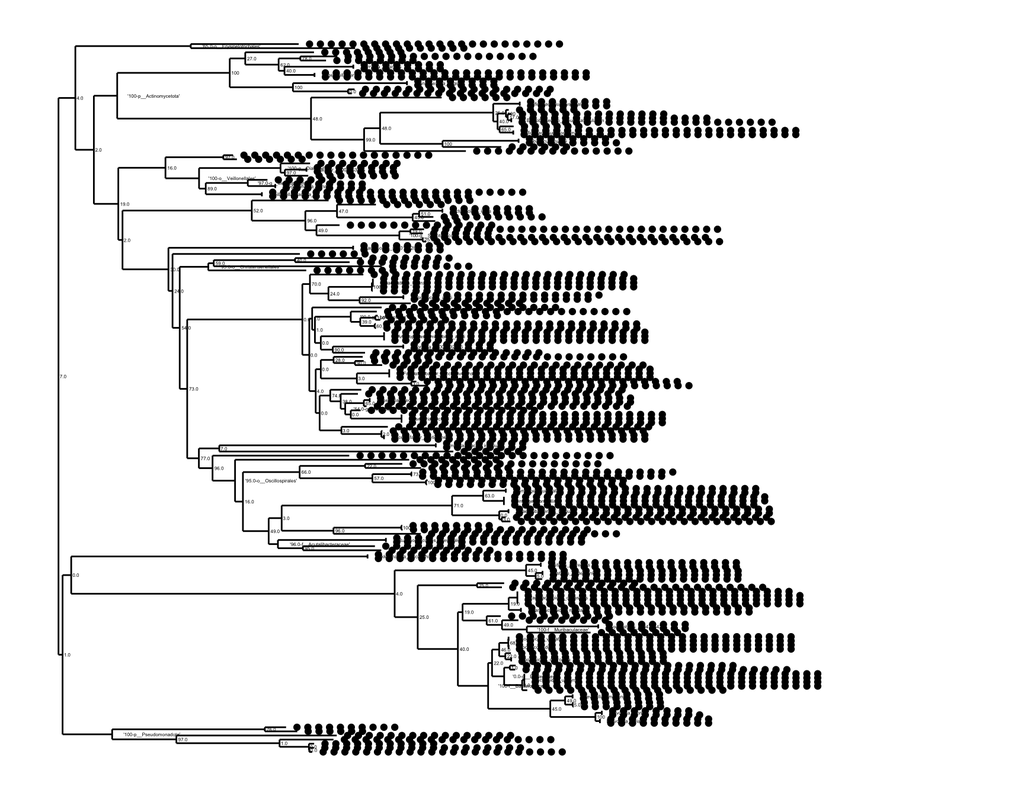

```r
plot_tree(ps)
```

In the resulting tree, we can see the MAGs at the tips of the tree, and each dot represents their abundance in each sample. This is the simplest possible way to visualise it, but there are ways to make the plot look nicer. This is an example from the phyloseq tutorial webpage:

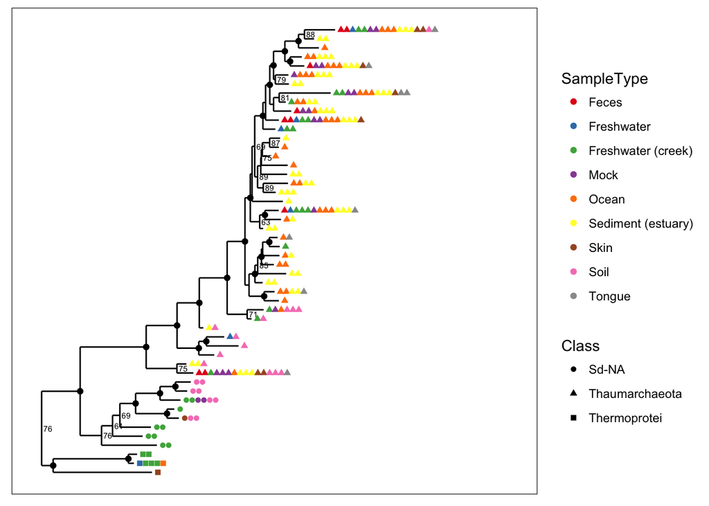

### Barplots of community composition

Barplots are one of the most common ways to visualise microbiome composition and are often easier to interpret than phylogenetic trees when first exploring a dataset.

In this example, taxa are coloured according to their phylum-level classification.

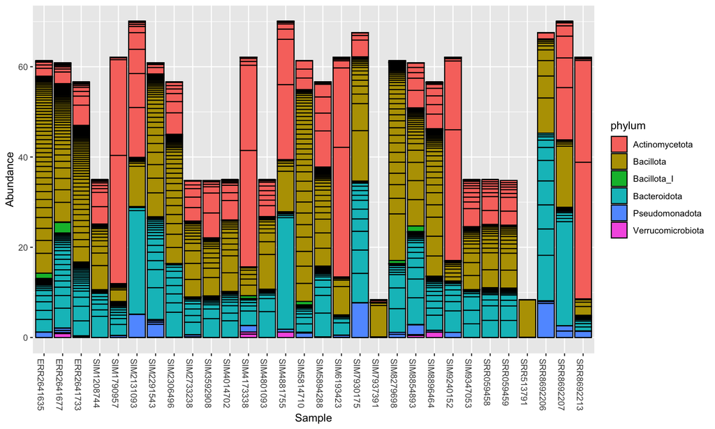

```r
plot_bar(ps, fill = "phylum")
```

### Heatmaps

Heatmaps are useful for simultaneously visualising patterns across both samples and taxa. However, large microbiome datasets can quickly become visually crowded, so these plots are often easier to interpret after filtering or taxonomic agglomeration.

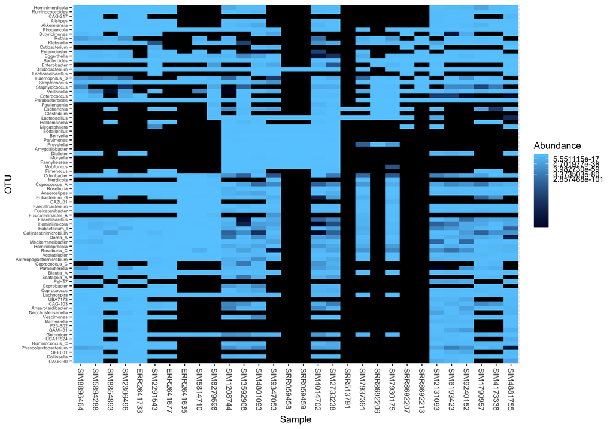

```r
plot_heatmap(ps_genus)
```

Here is a nice example of a heatmap:

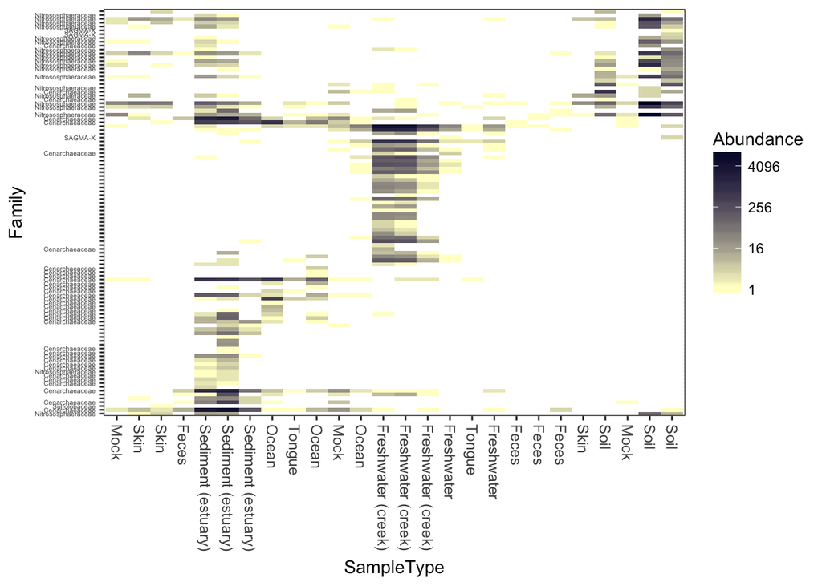

## Step 5: DIY

Now that you have explored some of the basic functionality of phyloseq, it is time to use it to explore your own dataset. Try to create a small set of exploratory analyses and visualisations to investigate what useful information can be extracted from the data.

Some suggested goals are:

1. Create barplots at different taxonomic levels, for example phylum, family, and genus, to identify preliminary patterns across samples or body sites.
2. Visualise the phylogenetic tree together with abundance information to explore whether certain phylogenetic groups are associated with specific samples or environments.
3. Generate heatmaps to identify taxa showing similar patterns across samples belonging to the same body site or experimental group.
4. Explore how filtering low-abundance taxa or low-depth samples affects the visualisation and interpretation of the data.
5. Try agglomerating the dataset at different taxonomic ranks and compare how the resulting plots change.

Remember that exploratory analysis is an important step in microbiome studies. The goal is not only to generate figures, but also to begin thinking critically about which biological patterns may or may not be supported by the data.

While using your favourite AI assistant might be tempting, all the information needed for this practical is already available in the phyloseq tutorials and documentation: https://joey711.github.io/phyloseq/index.html